# Données bleues

Des données québécoises pour enseigner la statistique et la science des données

Infrastructure pédagogique ouverte

# Données bleues

Des jeux de données québécois pour apprendre à importer, nettoyer, visualiser, modéliser et surtout interpréter avec contexte.

Beaucoup d’exemples pédagogiques en statistique, en programmation R et en science des données reposent sur des jeux de données non québécois, souvent américains. Ils peuvent être utiles, mais ils laissent souvent le territoire, les institutions, les licences, les unités statistiques et les limites loin de la salle de classe. Données bleues propose une autre entrée : des sources québécoises et canadiennes vérifiées, transformées en fiches, activités et pistes de projet.

Explorer le catalogue Commencer par une activité

La promesse

Passer d’un fichier trouvé en ligne à une ressource de cours complète : source, contexte, variables, limites, activité courte, activité longue et discussion pédagogique.

24

fiches de jeux de données

22

thèmes pédagogiques

48

activités prêtes à adapter

22

contextes d’enseignement

Point de départ

## Le contexte n’est pas une décoration. C’est une partie de la méthode.

Un jeu de données enseigne toujours plus que des colonnes. Il enseigne une façon de mesurer, une institution, une géographie, une licence, des choix de collecte, des angles morts et des limites d’interprétation.

Quand les exemples viennent presque toujours d’ailleurs, le geste statistique devient trop abstrait. On peut apprendre une fonction R ou un modèle, mais perdre la question la plus formatrice : qu’est-ce que ces données représentent réellement?

Données bleues remet ce contexte au centre. Le site aide à choisir des données locales, à les documenter correctement et à en faire du matériel pédagogique réutilisable plutôt qu’un exemple jetable.

Au lieu de demander seulement :

« Quel modèle appliquer? »

On apprend aussi à demander :

« Qui a produit ces données, pour quel usage, avec quelles limites, et que peut-on raisonnablement conclure? »

Ce que le site apporte

## Une source devient une séquence d’apprentissage.

Chaque fiche vise à réduire le temps de préparation tout en augmentant la qualité du contexte présenté aux personnes étudiantes.

01

### Trouver

Repérer rapidement une source québécoise par thème, niveau, concepts enseignables ou score zéro déchet.

02

### Comprendre

Identifier l’unité statistique, les variables principales, la provenance, la licence et les limites.

03

### Enseigner

Transformer la source en activité courte, laboratoire, mini-projet ou rapport reproductible.

04

### Réutiliser

Reprendre le même jeu de données dans plusieurs apprentissages : nettoyage, visualisation, inférence, modélisation, communication.

Par où commencer?

## Trois portes d’entrée, selon le besoin du moment.

Le site peut servir de catalogue de sources, de banque d’activités ou de cadre d’évaluation pédagogique.

01 / Catalogue

### Je cherche une source

Comparer les fiches par thème, niveau, concepts, format et potentiel pédagogique.

Ouvrir le catalogue

02 / Activités

### Je prépare une séance

Choisir une activité courte, une tâche longue ou un mini-projet déjà relié à une source.

Voir les activités

03 / Évaluation

### J’évalue un jeu de données

Utiliser la grille zéro déchet pour décider si une source mérite d’être préparée.

Lire le cadre

Exemples

## Trois fiches qui montrent l’esprit du projet.

Ces fiches couvrent des réalités proches de la classe : mobilité, environnement, finances municipales et données publiques documentées.

[figure not shown]

Mobilité urbaine

### BIXI

État des stations BIXI

**25 / 30**Ouvrir la fiche

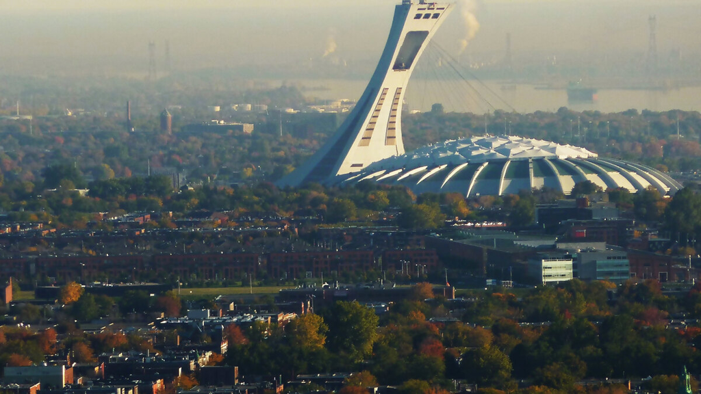

Environnement

### Air Québec

Qualité de l'air au Québec

**27 / 30**Ouvrir la fiche

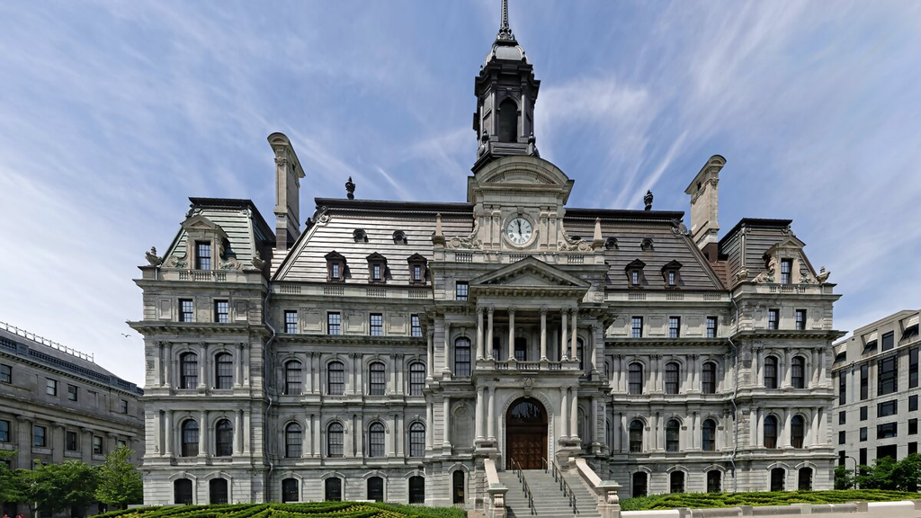

Finances et fiscalité municipales

### Profil financier

Profil financier des municipalités locales du Québec

**27 / 30**Ouvrir la fiche

Catalogue actuel

## Une base locale qui grandit.

Cette version contient 24 fiches réparties dans 22 thèmes pédagogiques. Les thèmes les plus visibles dans le catalogue actuel sont : Environnement, Éducation et territoire, Culture et services publics, Démographie, Finances et fiscalité municipales, Foresterie urbaine.

Le projet couvre notamment l’eau, l’environnement, la mobilité, l’éducation, la démographie, les services publics, le territoire et les données institutionnelles. Les sources et leurs dates d’accès sont listées dans les références.

Consulter les sources À propos du projet

Finalité

## Enseigner avec des données qui ont une adresse.

Données bleues avance par sources vérifiées, activités testables, scripts reproductibles et limites explicites. L’objectif est simple : rendre les exemples de statistique et de science des données plus situés, plus réutilisables et plus honnêtes.

Contribuer